# ExtraaLearn Project

#### Grid search 2

We could repeat the grid search, but e.g. tune less parameters.

```python
# Choose the type of classifier, we add the class weights, as it is unbalanced. Without these class weights, the results are worse for what we want to model for.
model_dt_tuned_2 = DecisionTreeClassifier(random_state = 1, class_weight = {0: 0.298, 1: 0.702})

# Grid of parameters to choose from
parameters = {'max_depth': np.arange(2, 8),
              'criterion': ['entropy', 'gini'],
             }
```

Here we do not consider the maximum features as a parameter to tune.

```python
# Run the search
grid_obj = GridSearchCV(model_dt_tuned_2, parameters, cv=5,scoring='recall',n_jobs=-1)
grid_obj = grid_obj.fit(X_train, y_train)

# Set the classifier to the best combination of parameters
model_dt_tuned_2 = grid_obj.best_estimator_

# Fit the best algorithm to the data.
model_dt_tuned_2.fit(X_train, y_train)
```

```
DecisionTreeClassifier(class_weight={0: 0.298, 1: 0.702}, criterion='entropy',
                       max_depth=3, random_state=1)
```

We check the performance:

```
Classification Report:

              precision    recall  f1-score   support

           0       0.95      0.75      0.84      2264
           1       0.60      0.91      0.72       964

    accuracy                           0.79      3228
   macro avg       0.78      0.83      0.78      3228
weighted avg       0.85      0.79      0.80      3228
```

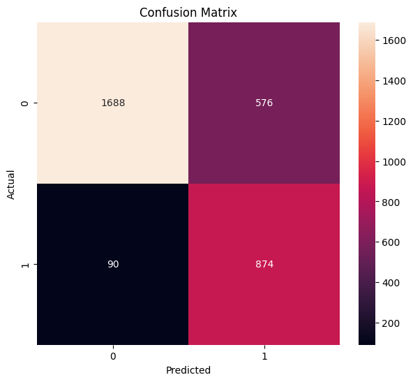

```python
# Checking performance on the training dataset
dt_pred_tuned_train_2 = model_dt_tuned_2.predict(X_train)
metrics_score(y_train,dt_pred_tuned_train_2)
```

```
Classification Report:

              precision    recall  f1-score   support

           0       0.94      0.73      0.82       971
           1       0.58      0.89      0.70       413

    accuracy                           0.78      1384
   macro avg       0.76      0.81      0.76      1384
weighted avg       0.83      0.78      0.79      1384
```

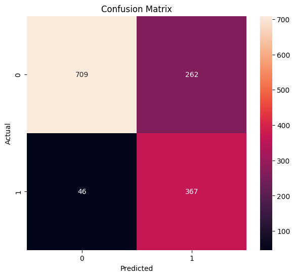

```python
# Checking performance on the test dataset
dt_pred_tuned_test_2 = model_dt_tuned_2.predict(X_test)
metrics_score(y_test,dt_pred_tuned_test_2)
```

We can see that the model is still well tuned, but slightly worse than the tuning including the 'maximum features' parameter done earlier. In this case, the model is however also slightly simpler, with only a maximum depth of 3.

The recall of this model is a bit lower (around 0.9) and the precision a bit higher (around 0.6). As always, no model is perfect and it will be a trade-off. It is just good to see that with a fairly simple model we can still reach satisfactory results here.

Let's visualize the tree again:

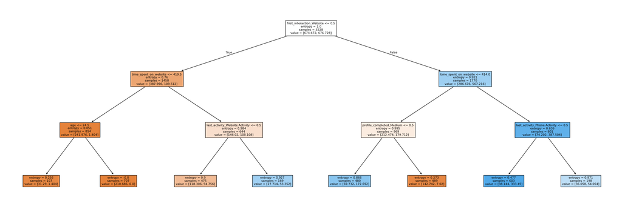

```python
# Plot the second  tuned tree till maximum depth of 3
feature_names = list(X_train.columns)
plt.figure(figsize=(30, 10))
tree.plot_tree(model_dt_tuned_2, max_depth=3, feature_names=feature_names, filled=True, fontsize=8, node_ids=False, class_names=None)

plt.show()
```

The color code in the tree is the same as in the previous model.

The feature importances for this second model are as follows:

```python
print(round(pd.DataFrame(model_dt_tuned_2.feature_importances_, columns = ["importance [%]"], index = X_train.columns).sort_values(by = 'importance [%]', ascending = False)*100,2))
```

```
                                importance [%]
time_spent_on_website                    36.56
first_interaction_Website                31.34
profile_completed_Medium                 23.38
last_activity_Phone Activity              4.82
last_activity_Website Activity            3.20
age                                       0.69
website_visits                            0.00
page_views_per_visit                      0.00
current_occupation_Student                0.00
current_occupation_Unemployed             0.00
profile_completed_Low                     0.00
print_media_type1_Yes                     0.00
print_media_type2_Yes                     0.00
digital_media_Yes                         0.00
educational_channels_Yes                  0.00
referral_Yes                              0.00
```

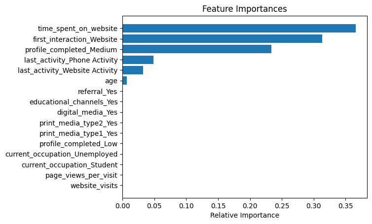

```python
# Feature importances
importances = model_dt_tuned_2.feature_importances_
indices = np.argsort(importances)

plt.title("Feature Importances")
plt.barh(range(len(indices)), importances[indices],align="center")
plt.yticks(range(len(indices)), [feature_names[i] for i in indices])
plt.xlabel("Relative Importance")
plt.show()
```

Here the main feature are largely similar as in the first model (first 3 are the same), but the age is basically replacing the occupation feature in the list of important parameters (however less important). The last activity is also more important. All the other features have no impact.

The small differences between the similar decision tree models 1 and 2 show that no model is perfect and variations are possible. Maybe due to the greater simplicity the second one might be preferred, but the recall score (=our target) of the first one is slightly better.

## Building a Random Forest model

Similar to the decision tree, we start building the untuned model

```python
# We use the decision tree classifier to fit on the training data set. We add the class weights (which we just calculated), as it is unbalanced.
model_rf = RandomForestClassifier(random_state=1, class_weight = {0: 0.298, 1: 0.702})
model_rf.fit(X_train, y_train)
```

```
RandomForestClassifier(class_weight={0: 0.298, 1: 0.702}, random_state=1)
```

We check the performance of the first model:

```
Classification Report:

              precision    recall  f1-score   support

           0       1.00      1.00      1.00      2264
           1       1.00      1.00      1.00       964

    accuracy                           1.00      3228
   macro avg       1.00      1.00      1.00      3228
weighted avg       1.00      1.00      1.00      3228
```

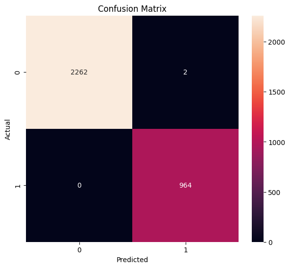

```python
# Evaluate performance on the training dataset
pred_train_rf = model_rf.predict(X_train)
metrics_score(y_train, pred_train_rf)
```

The suspiciously good recall and precision points towards overfitting.

```
Classification Report:

              precision    recall  f1-score   support

           0       0.88      0.92      0.90       971
           1       0.80      0.71      0.75       413

    accuracy                           0.86      1384
   macro avg       0.84      0.82      0.83      1384
weighted avg       0.86      0.86      0.86      1384
```

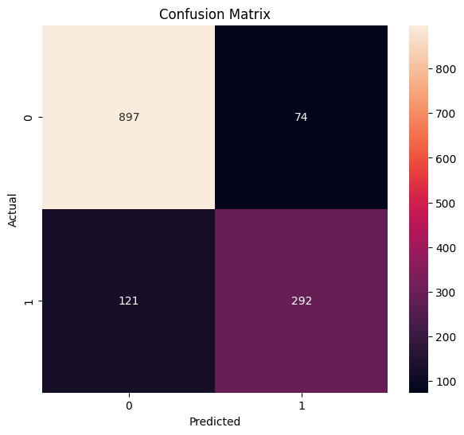

```python
# Evaluate performance on the training dataset
pred_test_rf = model_rf.predict(X_test)
metrics_score(y_test, pred_test_rf)
```

Even tough the performance on the test set is not too bad, it is a lot worse than the training set (and the previous decision tree models). This indicates that there is probably overfitting again. So we should could reduce the overfitting and improve the recall by hyperparameter tuning again.

## Do we need to prune the tree?

As just mentioned, the differences in performances between the test and train dataset, indicate that we should tune the model. In addition to the hyperparameters of the decision tree, there are some more possible here, like 'n_estimators'. We could take some of the parameters already closer to the ones obtained from the decision tree, but for clarity we will run a nearly complete analysis again. This will of course take a while to complete...

After that we can fine-tune a bit more and re-run.

```python
# Choose the type of classifier, we add the class weights, as it is unbalanced. Without these class weights, the results are worse for what we want to model for.
model_rf_tuned = RandomForestClassifier(random_state = 1, class_weight = {0: 0.298, 1: 0.702})

# Grid of parameters to choose from
parameters = {'max_depth': np.arange(2, 8),
              'criterion': ['entropy'], # First run showed 'entropy' to be preferred, 'gini' taken out after that
              'max_features': [0.7, 0.8, 0.9], # First run showed '0.8' to be preferred, only 0.7, 0.8 and 0.9 kept in consecutive re-runs ('srqt', 0.6, 0.5 not considered anymore)
              'n_estimators': [50, 75], # First run preferred 50 above 100, second run was with 75 added
              "min_samples_leaf": [10, 20], # First run preferred 20 above 25, second run was with 10 added
              "max_samples": [0.7, 0.8, 0.9], # First run preferred 0.8, later runs where focusing around this value
             }
```

```python
# Run the search
grid_obj = GridSearchCV(model_rf_tuned, parameters, cv=5,scoring='recall',n_jobs=-1)
grid_obj = grid_obj.fit(X_train, y_train)

# Set the classifier to the best combination of parameters
model_rf_tuned = grid_obj.best_estimator_

# Fit the best algorithm to the data.
model_rf_tuned.fit(X_train, y_train)
```

```
RandomForestClassifier(class_weight={0: 0.298, 1: 0.702}, criterion='entropy',
                       max_depth=3, max_features=0.7, max_samples=0.9,
                       min_samples_leaf=10, n_estimators=75, random_state=1)
```

```
Classification Report:

              precision    recall  f1-score   support

           0       0.95      0.75      0.84      2264
           1       0.61      0.91      0.73       964

    accuracy                           0.80      3228
   macro avg       0.78      0.83      0.78      3228
weighted avg       0.85      0.80      0.81      3228
```

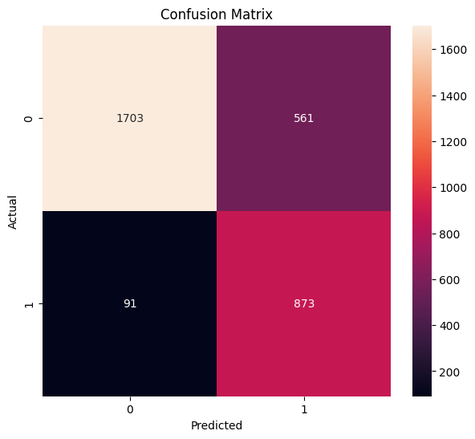

```python
# Checking performance on the training dataset
rf_pred_tuned_train = model_rf_tuned.predict(X_train)
metrics_score(y_train,rf_pred_tuned_train)
```

```
Classification Report:

              precision    recall  f1-score   support

           0       0.94      0.74      0.83       971
           1       0.59      0.89      0.71       413

    accuracy                           0.78      1384
   macro avg       0.76      0.81      0.77      1384
weighted avg       0.84      0.78      0.79      1384
```

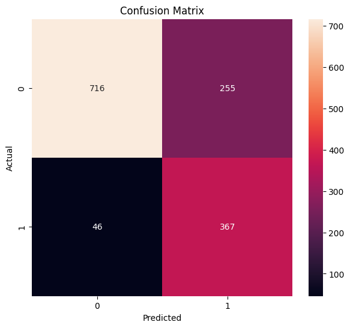

```python
# Checking performance on the test dataset
rf_pred_tuned_test = model_rf_tuned.predict(X_test)
metrics_score(y_test,rf_pred_tuned_test)
```

Conclusions:

- Some consecutive re-runs were done, playing with different hyperparameters and improving the model. However, at the end none of them significantly improved the performance on the train/test set.
- The achieved level (with a recall of around 90%) is however already satisfying. It is remarkable to see that the random forest is performing at a similar level as the simpler decision tree model, but is slightly worse (96% recall for our first decision tree model).
- Again the accuracy level is a pay-off with the recall.

Visualizing a random forest is hard and it is not possible to analyse it is a similar way as a decision tree. We can however look at the feature importance again.

```python
print(round(pd.DataFrame(model_rf_tuned.feature_importances_, columns = ["importance [%]"], index = X_train.columns).sort_values(by = 'importance [%]', ascending = False)*100,4))
```

```
                                importance [%]
time_spent_on_website                  36.2614
first_interaction_Website              36.1408
profile_completed_Medium               17.3946
last_activity_Phone Activity            3.2872
last_activity_Website Activity          2.6862
age                                     2.0364
current_occupation_Student              1.5197
profile_completed_Low                   0.3421
current_occupation_Unemployed           0.1102
page_views_per_visit                    0.0986
website_visits                          0.0880
referral_Yes                            0.0348
print_media_type2_Yes                   0.0000
print_media_type1_Yes                   0.0000
digital_media_Yes                       0.0000
educational_channels_Yes                0.0000
```

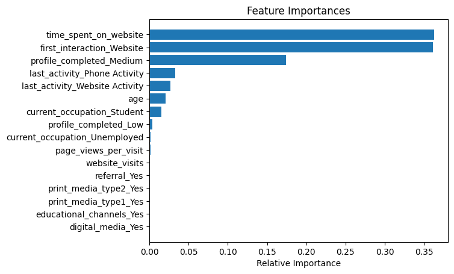

```python
# Feature importances
importances = model_rf_tuned.feature_importances_
indices = np.argsort(importances)

plt.title("Feature Importances")
plt.barh(range(len(indices)), importances[indices],align="center")
plt.yticks(range(len(indices)), [feature_names[i] for i in indices])
plt.xlabel("Relative Importance")
plt.show()
```

Conclusions:

- As similar order of importances can be found as for the decision tree models. 'time spent on website', 'first_interaction_website' and 'profile_completed_medium' are the 3 most important features.
- In contrast with the decision tree, there are more features with a non-zero influence. In fact, when listing the importances without rounding we can see that only 'digital_media' and 'educational_channels' have no impact in the model.

```python
print(pd.DataFrame(model_rf_tuned.feature_importances_, columns = ["importance [%]"], index = X_train.columns).sort_values(by = 'importance [%]', ascending = False))
```

```
                                importance [%]
time_spent_on_website             3.626135e-01
first_interaction_Website         3.614080e-01
profile_completed_Medium          1.739458e-01
last_activity_Phone Activity      3.287196e-02
last_activity_Website Activity    2.686182e-02
age                               2.036421e-02
current_occupation_Student        1.519695e-02
profile_completed_Low             3.420608e-03
current_occupation_Unemployed     1.102499e-03
page_views_per_visit              9.864769e-04
website_visits                    8.804881e-04
referral_Yes                      3.476853e-04
print_media_type2_Yes             1.770894e-17
print_media_type1_Yes             5.345369e-18
digital_media_Yes                 0.000000e+00
educational_channels_Yes          0.000000e+00
```

## Actionable Insights and Recommendations

##### Model performances:

We tuned the decision tree twice and the random forest once. In general, the results are very similar, with these results:

```python
print("First tuned decision tree:")
print(classification_report(y_test,dt_pred_tuned_test))
print("-"*60)
print("Second tuned decision tree:")
print(classification_report(y_test,dt_pred_tuned_test_2))
print("-"*60)
print("Tuned random forest:")
print(classification_report(y_test,rf_pred_tuned_test))
print("-"*60)
```

```
First tuned decision tree:
              precision    recall  f1-score   support

           0       0.97      0.61      0.75       971
           1       0.51      0.96      0.67       413

    accuracy                           0.72      1384
   macro avg       0.74      0.79      0.71      1384
weighted avg       0.84      0.72      0.73      1384

------------------------------------------------------------
Second tuned decision tree:
              precision    recall  f1-score   support

           0       0.94      0.73      0.82       971
           1       0.58      0.89      0.70       413

    accuracy                           0.78      1384
   macro avg       0.76      0.81      0.76      1384
weighted avg       0.83      0.78      0.79      1384

------------------------------------------------------------
Tuned random forest:
              precision    recall  f1-score   support

           0       0.94      0.74      0.83       971
           1       0.59      0.89      0.71       413

    accuracy                           0.78      1384
   macro avg       0.76      0.81      0.77      1384
weighted avg       0.84      0.78      0.79      1384

------------------------------------------------------------
```

Observations:

- The recall for the conversions (y=1) is best for the first tuned decision tree (96%), but the difference with the second decision tree and the random forest is not too big. Given the simplicity of the second decision tree (less depth), this model might be preferred in some cases.
- The recall is a trade-off with the precision, which is for y=1 typically around 0.6 (second decision tree and random forest) or 0.5 (first decision tree)

##### Feature importances:

```python
print("Importance features")
print("-"*60)
print("First tuned decision tree:")
print(pd.DataFrame(model_dt_tuned.feature_importances_, columns = ["importance [%]"], index = X_train.columns).sort_values(by = 'importance [%]', ascending = False)[0:5]*100)
print("-"*60)
print("Second tuned decision tree:")
print(pd.DataFrame(model_dt_tuned_2.feature_importances_, columns = ["importance [%]"], index = X_train.columns).sort_values(by = 'importance [%]', ascending = False)[0:5]*100)
print("-"*60)
print("Tuned random forest:")
print(pd.DataFrame(model_rf_tuned.feature_importances_, columns = ["importance [%]"], index = X_train.columns).sort_values(by = 'importance [%]', ascending = False)[0:5]*100)
```

```
Importance features
------------------------------------------------------------
First tuned decision tree:
                                importance [%]
time_spent_on_website                37.457308
first_interaction_Website            27.790547
profile_completed_Medium             20.966677
current_occupation_Student            7.898949
last_activity_Website Activity        2.900032
------------------------------------------------------------
Second tuned decision tree:
                                importance [%]
time_spent_on_website                36.564351
first_interaction_Website            31.341039
profile_completed_Medium             23.382563
last_activity_Phone Activity          4.823640
last_activity_Website Activity        3.200302
------------------------------------------------------------
Tuned random forest:
                                importance [%]
time_spent_on_website                36.261353
first_interaction_Website            36.140800
profile_completed_Medium             17.394578
last_activity_Phone Activity          3.287196
last_activity_Website Activity        2.686182
```

Observations:

- For sure the 'time spent on the website', the 'first interaction' and the 'profile completion' are important parameters. They are the prevailing ones in all three models. Logically, their impact is not the same for all three models.
- the 'last_activity' is the 4th/5th most important feature in the 2nd and 3rd model. The first model however takes 'occupation' more into account.

##### Recommandations:

- Our first tuned decision tree gives the best recall value. As that is preferred, this is the best model to use.
- Focus should be on the main influencing parameters like 'time spent on the website', the 'first interaction' and the 'profile completion'. When the last activity is on the website, the conversion chance in higher, the same is valid if the profile is filled to a higher degree.
- Because the conversion rate is a lot higher when the first interaction is over the website, one could question if the mobile application should be improved. Is there a reason why the conversion rate would be so much lower there?
- The age or occupation has also influence on the conversion rate. Younger people/students buy the educational package a lot less. A dedicated student package (cheap deal) to increase the conversion for students could therefor be an interesting path to follow.